# Data visualisation

Gerko Vink, Erik-Jan van Kesteren & Anne Vinkel Hansen

Statistical Programming with R

## We use the following packages

```r
library(MASS)     # Datasets
library(mice)     # Boys dataset
library(dplyr)    # Data manipulation
library(magrittr) # Pipes
library(ggplot2)  # Plotting suite
library(sf)       # Spatial features
```

## Visualising in R

- R makes it very easy to visualise data
- But fine-tuning figures to specific standards can take a lot of time

### Why visualise?

- We can process a lot of information quickly with our eyes
- More intuitively accessible to laymen
- Plots give us information about
  - Distribution / shape
  - Irregularities
  - Assumptions
  - Intuitions

## What we will do

- A few plots in `base` graphics in `R`
- Plotting with `ggplot2` graphics
- Plotting data on maps

## `base` graphics in `R`

First, recall:

- Vectors

```r
height <- c(50.1, 53.5, 50.0, 54.5, 57.5)
weight <- c(3.65, 3.37, 3.14, 4.27, 5.03)
```

- Data frames

```r
boys <- boys
head(boys)
```

```
##      age  hgt   wgt   bmi   hc  gen  phb tv   reg
## 3  0.035 50.1 3.650 14.54 33.7 <NA> <NA> NA south
## 4  0.038 53.5 3.370 11.77 35.0 <NA> <NA> NA south
## 18 0.057 50.0 3.140 12.56 35.2 <NA> <NA> NA south
## 23 0.060 54.5 4.270 14.37 36.7 <NA> <NA> NA south
## 28 0.062 57.5 5.030 15.21 37.3 <NA> <NA> NA south
## 36 0.068 55.5 4.655 15.11 37.0 <NA> <NA> NA south
```

To call a variable in the data frame, use the $ notation:

```r
boys$hgt[1:10]
```

```
##  [1] 50.1 53.5 50.0 54.5 57.5 55.5 52.5 53.0 55.1 54.5
```

## Scatter plot

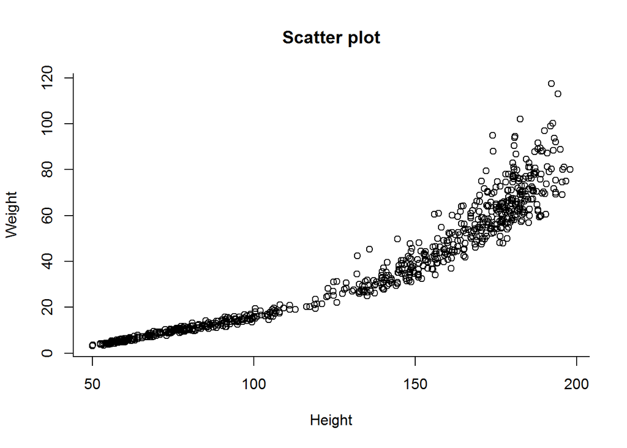

```r
plot(x = boys$hgt, y = boys$wgt, main = "Scatter plot",
     xlab = "Height", ylab = "Weight", bty = "L")
```

## Line chart

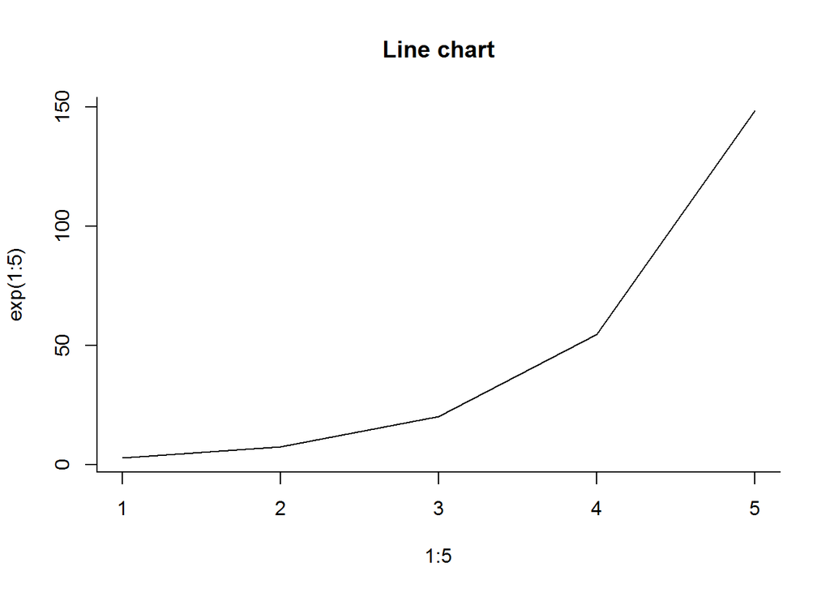

```r
plot(x = 1:5, y = exp(1:5), type = "l", main = "Line chart", bty = "L")
```

## Bar chart

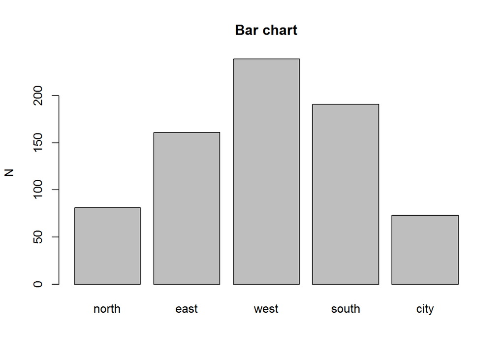

```r
counts <- table(boys$reg)

barplot(counts, main="Bar chart", ylab = "N")
```

## Pie chart

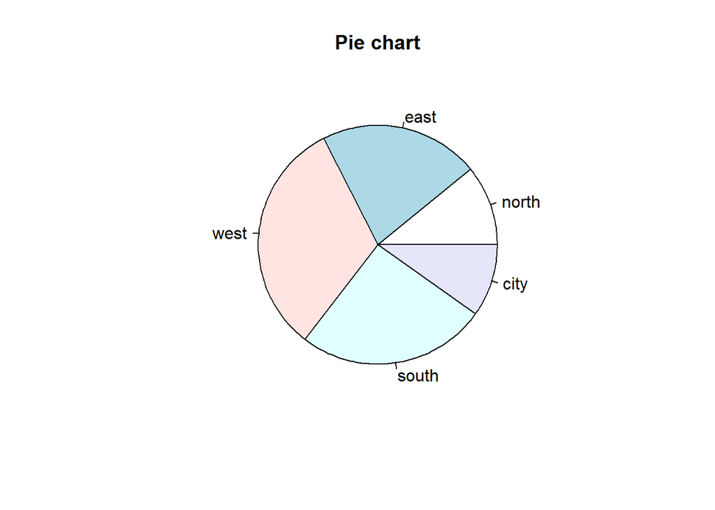

```r
counts <- table(boys$reg)

pie(x=counts, main="Pie chart")
```

## Histogram

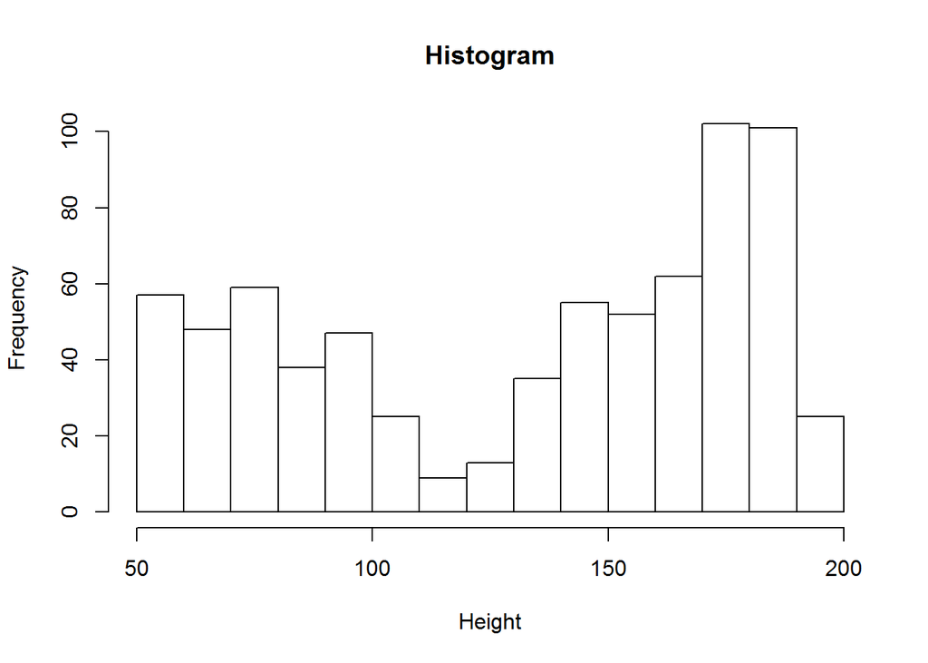

```r
hist(boys$hgt, main = "Histogram", xlab = "Height")
```

## Box plot

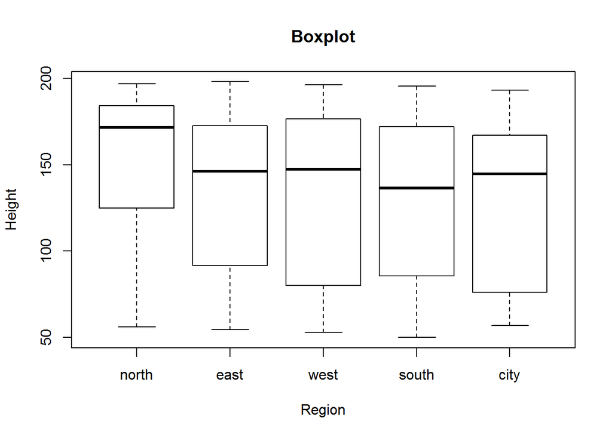

```r
boxplot(boys$hgt ~ boys$reg, main = "Boxplot",
        xlab = "Region", ylab = "Height")
```

## But what if we want more control?

# ggplot2

## What is `ggplot2`?

Layered plotting based on the book **The Grammar of Graphics** by Leland Wilkinsons.

With `ggplot2` you

1. provide the *data*
2. define how to map variables to *aesthetics*
3. state which *geometric object* to display
4. (optional) edit the overall *theme* of the plot

`ggplot2` then takes care of the details

## An example: scatterplot

1: Provide the data

```r
boys %>%
  ggplot()
```

2: map variable to aesthetics

```r
boys %>%
  ggplot(aes(x = age, y = bmi))
```

3: state which geometric object to display

```r
boys %>%
  ggplot(aes(x = age, y = bmi)) +
  geom_point()
```

## An example: scatterplot

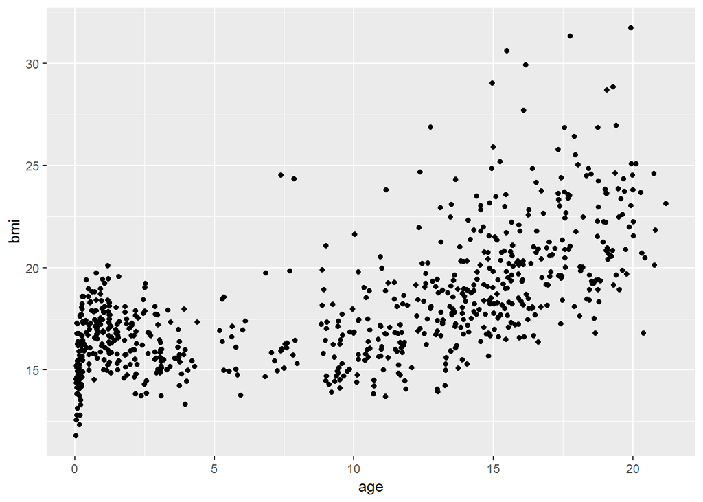

## Why this syntax?

Create the plot

```r
gg <-
  boys %>%
  ggplot(aes(x = age, y = bmi)) +
  geom_point()
```

Add another layer (smooth fit line)

```r
gg <- gg +
  geom_smooth(col = "dark blue")
```

Give it some labels and a nice look

```r
gg <- gg +
  labs(x = "Age", y = "BMI", title = "BMI trend for boys") +
  theme_minimal()
```

## Why this syntax?

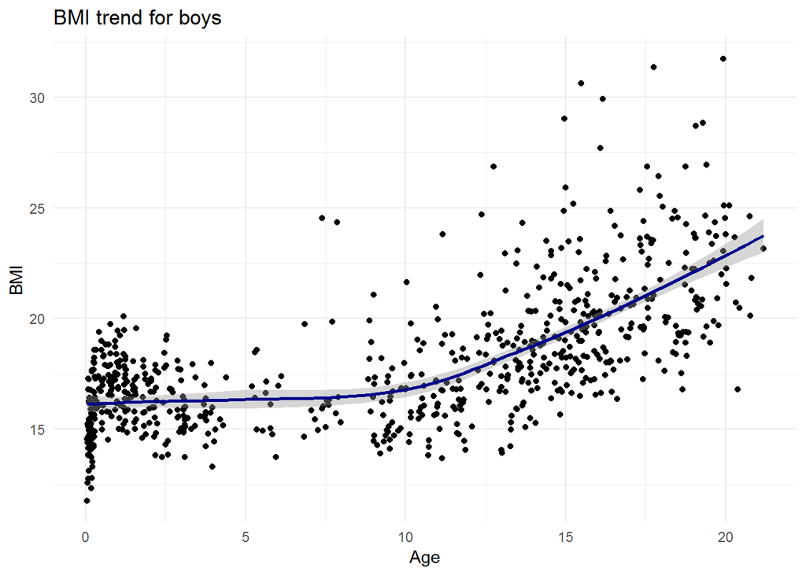

```r
plot(gg)
```

## Why this syntax?

[figure not shown]

## Aesthetics

- x
- y
- size
- colour
- fill
- opacity (alpha)
- linetype
- …

## Aesthetics

```r
gg <-
  boys %>%
  filter(!is.na(reg)) %>%

  ggplot(aes(x      = age,
             y      = bmi,
             size   = hc,
             colour = reg)) +

  geom_point(alpha = 0.5) +

  labs(title  = "BMI trend for boys",
       x      = "Age",
       y      = "BMI",
       size   = "Head circumference",
       colour = "Region") +
  theme_minimal()
```

## Aesthetics

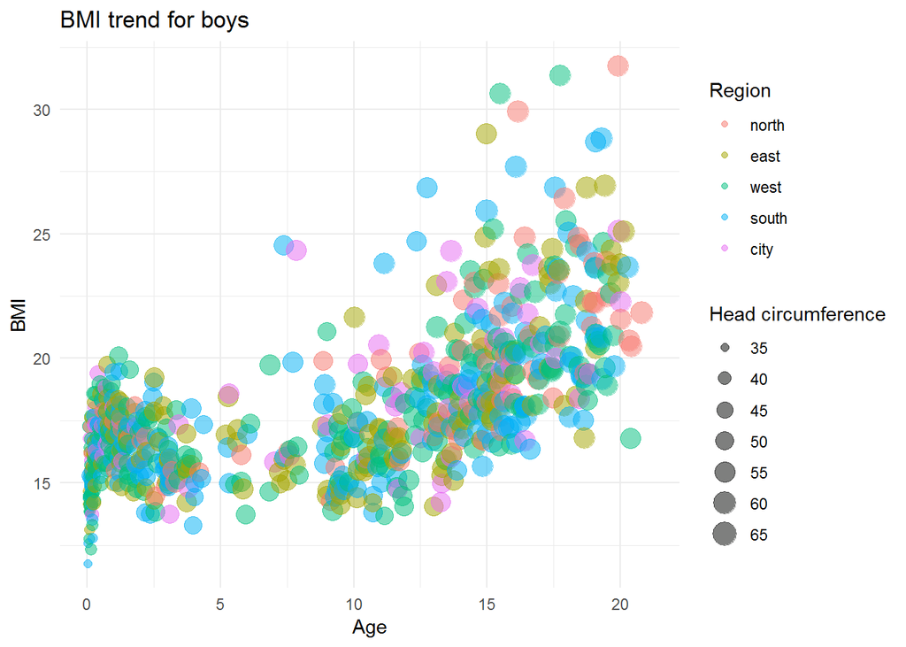

```r
plot(gg)
```

## Geoms

- geom_point
- geom_bar
- geom_line
- geom_smooth
- geom_histogram
- geom_boxplot
- geom_density

## Geoms: Bar

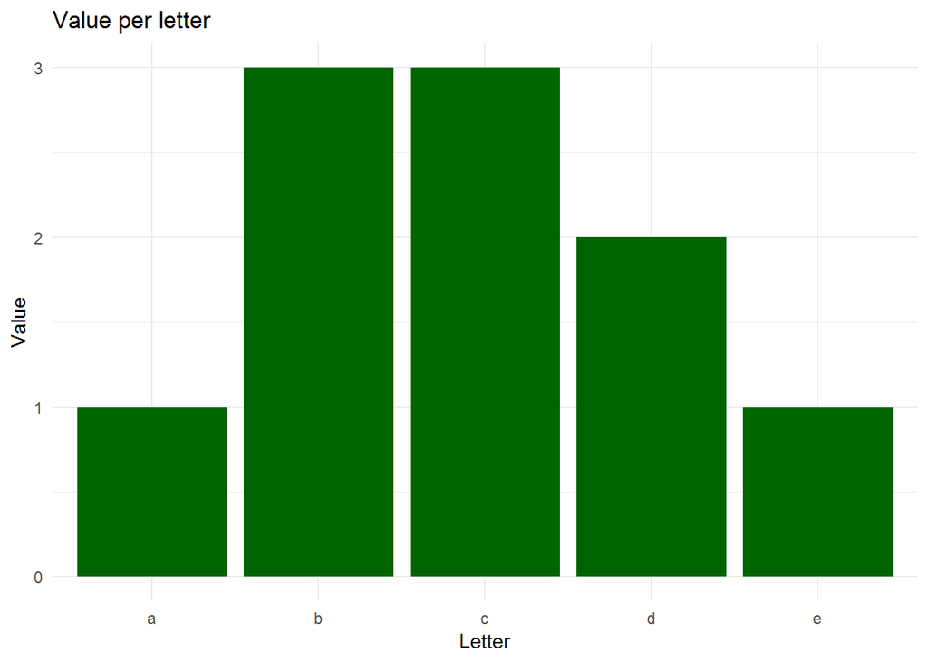

## Geoms: Line

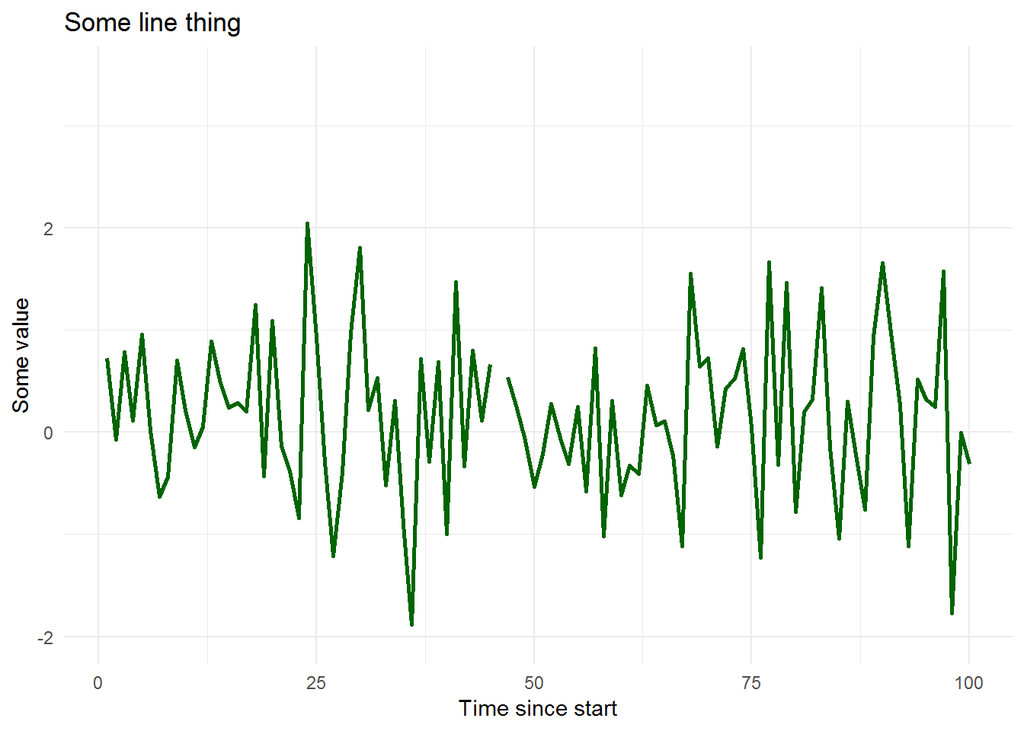

## Geoms: Smooth

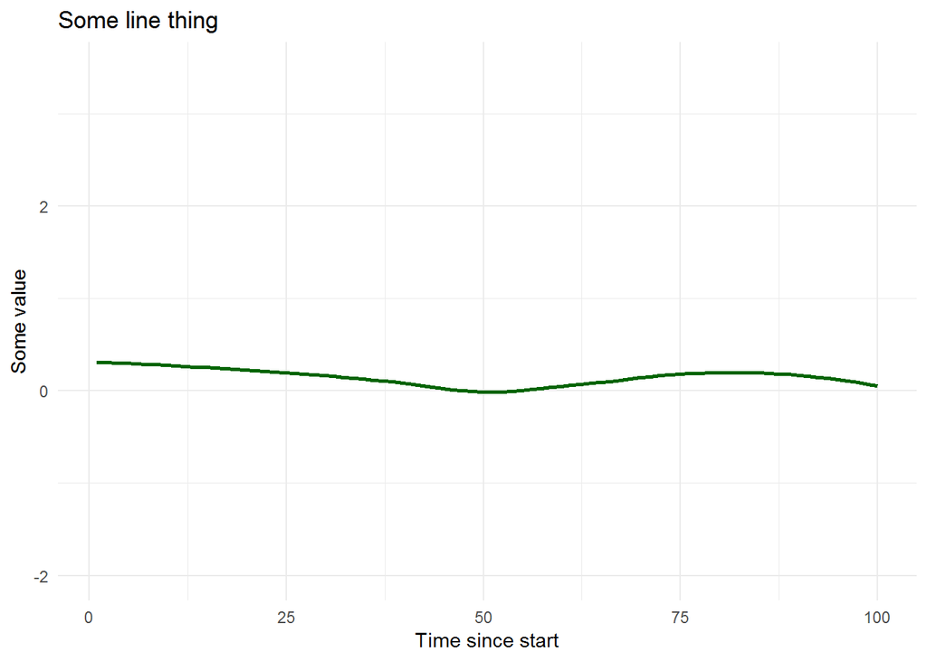

## Geoms: Boxplot

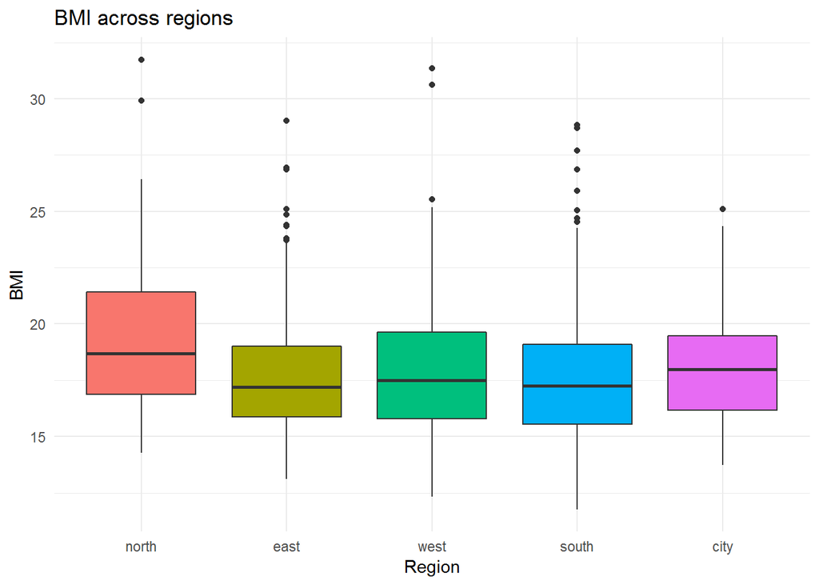

## Helpful link in RStudio

[figure not shown]

# Maps

## Simple Features

- A formal standard (ISO 19125-1:2004) that describes how objects in the real world can be represented in computers, with emphasis on the spatial geometry of these objects.
- As implemented e.g. in ArcGIS
- Implemented for R in the `sf` package
- Feature geometries are stored in `data.frames`

We have time for a cursory introduction at most.

## Reading in spatial data

```r
denmark <- st_read("DK_map.shp")
```

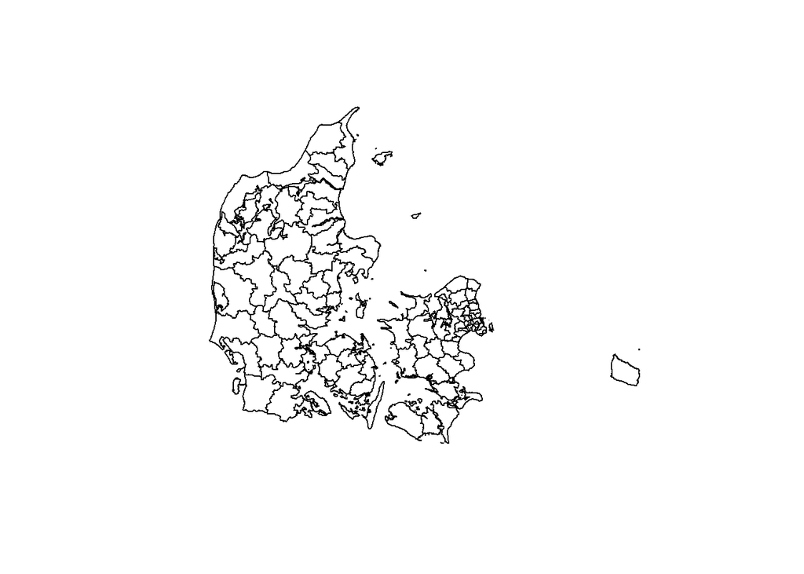

```r
plot(st_geometry(denmark))
```

## Plotting regional attributes

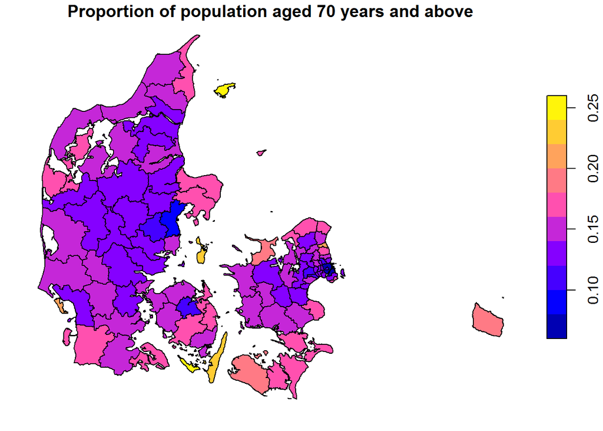

```r
denmark$proportion.over.70 <- denmark$over70/denmark$population

plot(denmark["proportion.over.70"],
     main = "Proportion of population aged 70 years and above")
```

## Or we can `ggplot`

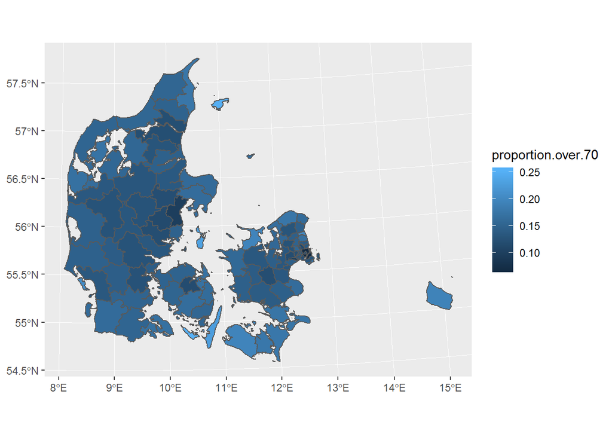

```r
denmark %>% ggplot(aes(fill=proportion.over.70)) + geom_sf()
```